# My findings in TMDb Movie Dataset

## by Raghad al-onazie

## Investigation Overview

The goal of this presentation is to ask some questions mainly about the relationships between movie budgets, revenue, ratings and their popularity.

## Dataset Overview

For my project, I have chosen to work with the TMDb Movies dataset. This is a large dataset that stores information about most popular (and also less popular) movies such as:

- **popularity:** This is a measure of a movie's popularity.
- **vote count:** The number of votes a given movie has received.
- **vote average:** This is the average rating of a given movie.
- **budget_adj:** This is the adjusted budget of a given movie. This takes into account the inflation factor of currency.
- **revenue_adj:** This is the adjusted revenue of a given movie. This takes into account the inflation factor of currency.

## Key findings

In a nutshell, the main findings conveyed by the following slides show that movies with small budgets can be popular and be rated as well as movies with higher budgets. This is good news for amateurs and producers who do not have access to big budgets since they can still be successful as big produces and get high revenues.

## 1- How a movie's budget affects it rating?

In the following visualization, I want to explore whether movies with higher budgets have higher rating or not. One might expect that this is the case. However, the plot shows that the budget is not correlated with ratings. Small budgets can make great movies too. **Creativity does not need big money :)**

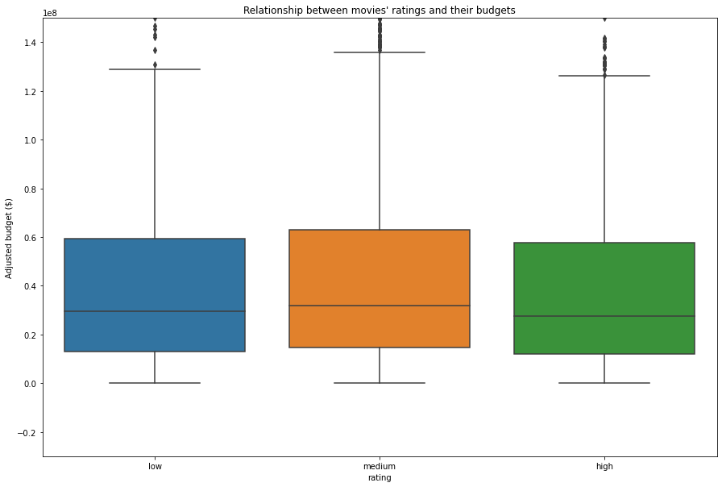

## 2- How a movie's revenue affects it rating?

Now, it would be interesting to explore whether movies with higher ratings has higher revenue. The following figure indicates that this is actually the case. This makes sense since movies that are better rated would potentially be more popular and sell more tickets

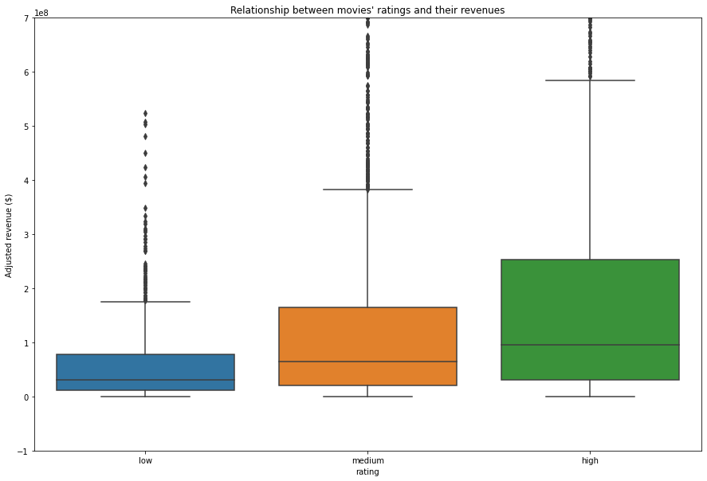

## 3 - What is the relationship between budget, revenue and popularity?

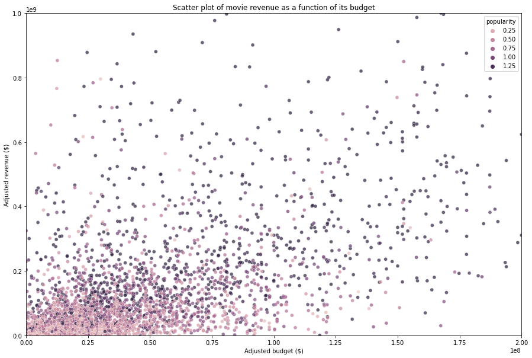

[output not shown]